# Bayes Testing

Ibraheem Khan

1/30/2022

# Bayes Testing- Setup

Bayes testing is a hypothesis testing procedure by which the null is rejected if the posterior probability of the tested parameter not lying in the null region is greater than some threshold probability. Suppose we want to test the mean $\theta$ of a Normally distributed random variable $X \sim N(\theta, \sigma^2)$ and our threshold $c=0.50$. Specifically, our null hypothesis is $H_0: \theta \leq -0.5$. Here we illustrate the Bayes testing procedure for this setup and we test it with various different priors and across different sample sizes.

# Sample Generation

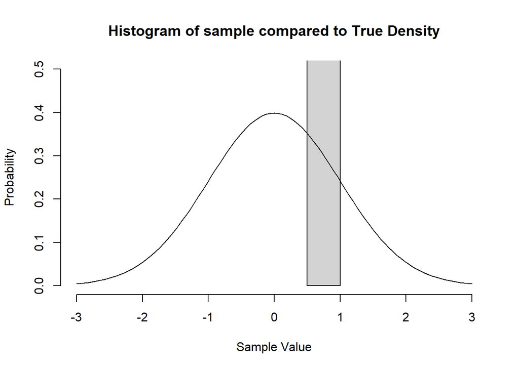

```r
#n <- 1 #sample size
n_select <- c(1,2,3,5,10,25,50,100)
for (n in n_select){
theta <- 0 #true mean
sigma <- 1 #true standard deviation
sample <- rnorm(n,theta,sigma)
sample_histogram<-hist(sample, prob=TRUE,
                       main="Histogram of sample compared to True Density",
                       xlab="Sample Value", ylab="Probability",
                       xlim=c(-3*sigma+theta,3*sigma+theta), ylim=c(0,0.5))
curve(dnorm(x,mean=theta,sd=sigma), add=TRUE)
}
```

# Prior

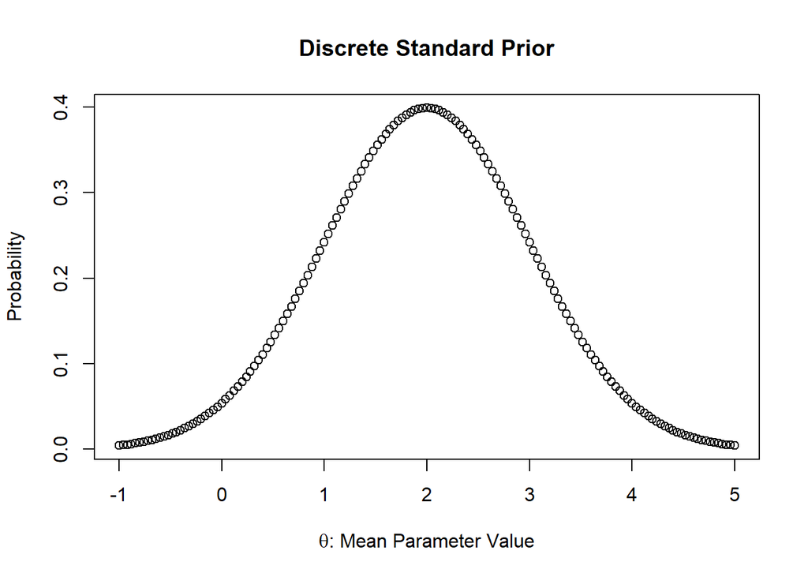

```r
mu <- 2
tau <- 1
bin_size <-1/25
grid <- seq(-3*tau+mu,3*tau+mu,by=bin_size)
standard_prior <- dnorm(grid,mu,tau)
plot(grid,standard_prior, main="Discrete Standard Prior",
     xlab=TeX('$\\theta$: Mean Parameter Value'), ylab="Probability")
```